## CENG 4515 - DATA SCIENCE AND ANALYTICS FINAL PROJECT

### Author : Süleyman Emre Parlak

### Dataset : Food Delivery Times

### 1. Please find your original dataset or datasets; and describe your data in the first step.

```r
library(dplyr)
data <- read.csv("C:/Users/emre-/Desktop/Food_Delivery_Times.csv")
data <- data %>%
  mutate(across(where(is.character), ~ na_if(., "")))
print(head(data))
```

```
##   Order_ID Distance_km Weather Traffic_Level Time_of_Day Vehicle_Type
## 1      522        7.93   Windy           Low   Afternoon      Scooter
## 2      738       16.42   Clear        Medium     Evening         Bike
## 3      741        9.52   Foggy           Low       Night      Scooter
## 4      661        7.44   Rainy        Medium   Afternoon      Scooter
## 5      412       19.03   Clear           Low     Morning         Bike
## 6      679       19.40   Clear           Low     Evening      Scooter
##   Preparation_Time_min Courier_Experience_yrs Delivery_Time_min
## 1                   12                      1                43
## 2                   20                      2                84
## 3                   28                      1                59
## 4                    5                      1                37
## 5                   16                      5                68
## 6                    8                      9                57
```

I labeled the “” values as Na.

Key Features :

Order_ID : Unique identifier for each order.

Distance_km : The delivery distance in kilometers.

Weather : Weather conditions during the delivery. Including Clear, Rainy, Snowy, Foggy, Windy.

Traffic_Level : Traffic conditions categorized as Low, Medium or High.

Time_of_Day : The time when the delivery took place, categorized as Morning, Afternoon, Evening or Night.

Vehicle_Type : Type of vehicle used for delivery, including Bike, Scooter, and Car.

Preparation_Time_min : The time required to prepare the order, measured in minutes.

Courier_Experience_yrs : Experience of the courier in years.

Delivery_Time_min : The total delivery time in minutes.

### 2. Use “Explaratory data analysis”. Write down your comments.

```r
str(data)
```

```
## 'data.frame':    1000 obs. of  9 variables:
##  $ Order_ID              : int  522 738 741 661 412 679 627 514 860 137 ...
##  $ Distance_km           : num  7.93 16.42 9.52 7.44 19.03 ...
##  $ Weather               : chr  "Windy" "Clear" "Foggy" "Rainy" ...
##  $ Traffic_Level         : chr  "Low" "Medium" "Low" "Medium" ...
##  $ Time_of_Day           : chr  "Afternoon" "Evening" "Night" "Afternoon" ...
##  $ Vehicle_Type          : chr  "Scooter" "Bike" "Scooter" "Scooter" ...
##  $ Preparation_Time_min  : int  12 20 28 5 16 8 12 5 20 29 ...
##  $ Courier_Experience_yrs: num  1 2 1 1 5 9 1 6 6 1 ...
##  $ Delivery_Time_min     : int  43 84 59 37 68 57 49 46 35 73 ...
```

The dataset consists of 1,000 observations and 9 variables. Some of the variables are numerical, while others are categorical, represented as character types.

```r
missing_data_percentage <- colSums(is.na(data)) / nrow(data) * 100
print(colSums(is.na(data)))
```

```
##               Order_ID            Distance_km                Weather
##                      0                      0                     30
##          Traffic_Level            Time_of_Day           Vehicle_Type
##                     30                     30                      0
##   Preparation_Time_min Courier_Experience_yrs      Delivery_Time_min
##                      0                     30                      0
```

```r
print(missing_data_percentage)
```

```
##               Order_ID            Distance_km                Weather
##                      0                      0                      3
##          Traffic_Level            Time_of_Day           Vehicle_Type
##                      3                      3                      0
##   Preparation_Time_min Courier_Experience_yrs      Delivery_Time_min
##                      0                      3                      0
```

Here, I checked for missing values in the dataset. As observed, there are 30 missing values in the “Courier_Experience_yrs”,“Weather”,“Traffic_Level”,“Time_of_Day” columns, which means %3 data in each of these columns is missing (calculated as 30 * 100 / number of rows).

```r
library(dplyr)
numeric_columns <- data %>% select(Distance_km, Preparation_Time_min, Courier_Experience_yrs, Delivery_Time_min)
cor_matrix <- cor(numeric_columns, use = "complete.obs")

print(cor_matrix)
```

```
##                         Distance_km Preparation_Time_min Courier_Experience_yrs
## Distance_km             1.000000000         -0.009301628           -0.007842348
## Preparation_Time_min   -0.009301628          1.000000000           -0.030829890
## Courier_Experience_yrs -0.007842348         -0.030829890            1.000000000
## Delivery_Time_min       0.777820050          0.308425365           -0.090432925
##                        Delivery_Time_min
## Distance_km                   0.77782005
## Preparation_Time_min          0.30842537
## Courier_Experience_yrs       -0.09043293
## Delivery_Time_min             1.00000000
```

As I checked the correlation between the numerical variables, I found a strong positive correlation between distance and delivery time. There is a moderate positive correlation between preparation time and delivery time. Additionally, there is a slight negative correlation between courier experience and delivery time, indicating that the experience level does not have a significant impact on delivery time.

### 3. Use some “visualization techniques” and talk about your data further.

Let’s check if the weather affects delivery times based on the type of vehicle.

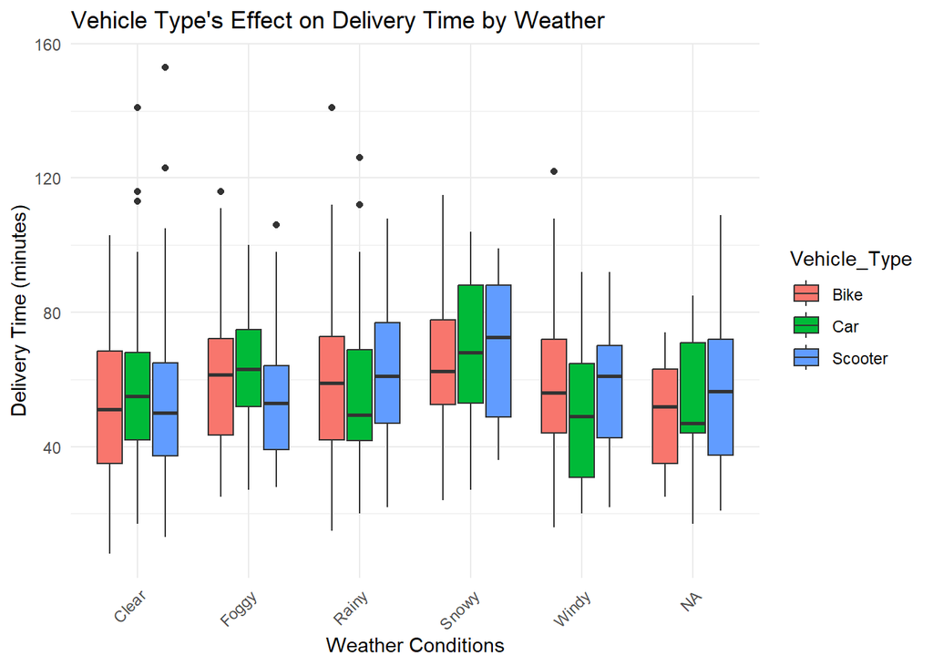

```r
library(ggplot2)

ggplot(data, aes(x = Weather, y = Delivery_Time_min, fill = Vehicle_Type)) +
  geom_boxplot() +
  labs(title = "Vehicle Type's Effect on Delivery Time by Weather",
       x = "Weather Conditions",
       y = "Delivery Time (minutes)") +
  theme_minimal() +
  theme(axis.text.x = element_text(angle = 45, hjust = 1))
```

Accordingly;

- Clear : On average, bikes and scooters are faster than cars. In some situations bike slower.
- Foggy : Scooter faster on average, car has min variance.
- Rainy : Car should be selected for faster delivery.
- Snowy : Bike faster on average and has min variance.
- Windy : On average, car is faster but has max variance.
- Other : Car is faster on average.

Now, let’s compare the time of day with the delivery time.

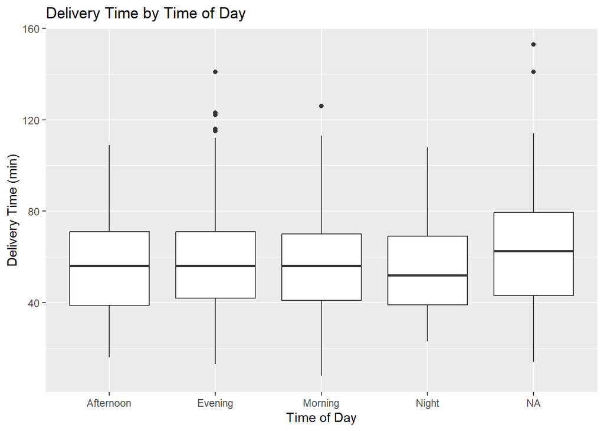

```r
ggplot(data, aes(x = Time_of_Day, y = Delivery_Time_min)) +
  geom_boxplot() +
  labs(title = "Delivery Time by Time of Day", x = "Time of Day", y = "Delivery Time (min)")
```

As observed, the ‘Time of Day’ has no significant effect on the delivery time. The outliers seen in the evening and morning could potentially be caused by traffic. During the night, I can only observe a slight difference with faster deliveries. The variances for all times of day are approximately the same.

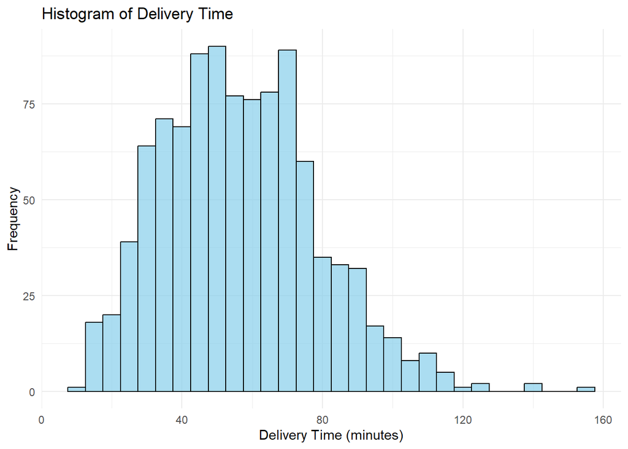

```r
ggplot(data, aes(x = Delivery_Time_min)) +
  geom_histogram(binwidth = 5, fill = "skyblue", color = "black", alpha = 0.7) +
  labs(title = "Histogram of Delivery Time", x = "Delivery Time (minutes)", y = "Frequency") +
  theme_minimal()
```

```r
mean(data$Delivery_Time_min)
```

```
## [1] 56.732
```

```r
max(data$Delivery_Time_min)
```

```
## [1] 153
```

```r
min(data$Delivery_Time_min)
```

```
## [1] 8
```

This histogram shows us the distribution of the Delivery_Time_min column. I can say that this is distributed like right skewed and established between 8 and 153. The mean is 56.732.

### 4. Check your data for multicollinearity, make your comments.

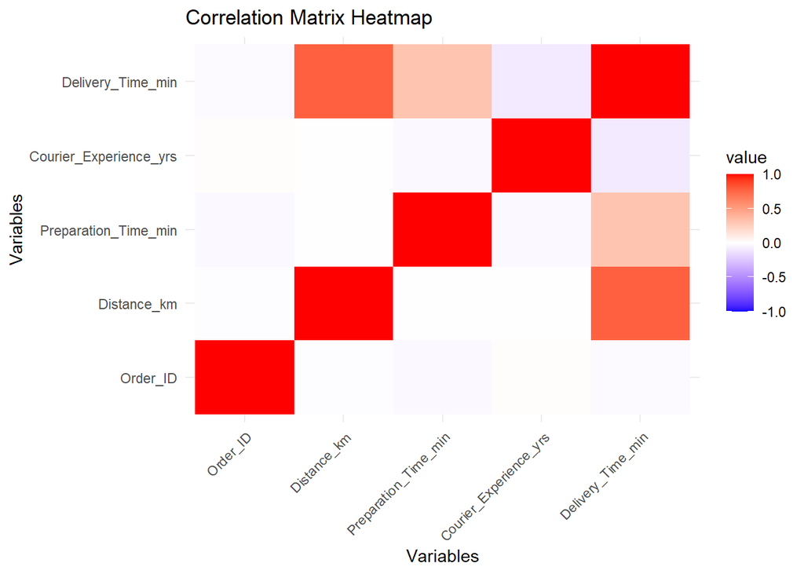

```r
library(reshape2)
cor_matrix <- cor(data[, sapply(data, is.numeric)], use = "complete.obs")
cor_melted <- melt(cor_matrix)

ggplot(cor_melted, aes(Var1, Var2, fill = value)) +
  geom_tile() +
  scale_fill_gradient2(low = "blue", high = "red", mid = "white", midpoint = 0, limit = c(-1, 1)) +
  theme_minimal() +
  labs(title = "Correlation Matrix Heatmap", x = "Variables", y = "Variables") +
  theme(axis.text.x = element_text(angle = 45, hjust = 1))
```

In this heatmap, I can see a strong correlation between Distance_km and Delivery_Time_min. I may need to consider removing or combining highly correlated variables, as high multicollinearity can lead to unstable estimates in regression models and negatively affect the model’s performance. Additionally, Preparation_Time_min has a weak correlation with Delivery_Time_min. At last, I would say that Courier_Experience_yrs does not have a significant impact on delivery time.

### 5. Apply PCA.

1. Use appropriate functions and arguments.

   ```r
   numerical_cols <- data[, c("Distance_km", "Preparation_Time_min", "Courier_Experience_yrs", "Delivery_Time_min")]
   data_finite <- numerical_cols[is.finite(rowSums(numerical_cols)),]
   num_data_scaled <- scale(data_finite)

   pca <- prcomp(num_data_scaled, center=TRUE, scale. = TRUE)
   summary(pca)
   ```

   ```
   ## Importance of components:
   ##                           PC1    PC2    PC3     PC4
   ## Standard deviation     1.3567 1.0139 0.9871 0.39624
   ## Proportion of Variance 0.4602 0.2570 0.2436 0.03925
   ## Cumulative Proportion  0.4602 0.7172 0.9607 1.00000
   ```

2. Use visualization techniques for PCA, describe the result!

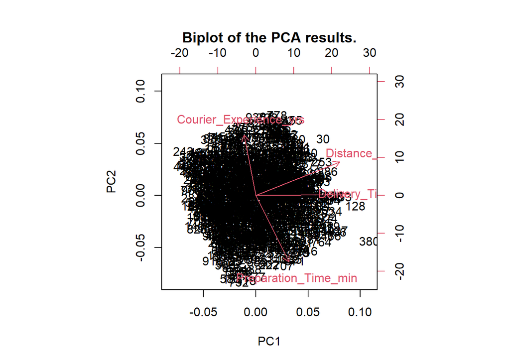

   ```r
   biplot(pca, main = "Biplot of the PCA results.")
   ```

   The PCA biplot shows strong correlation between Distance_km and Delivery_Time_min, while Courier_Experience_yrs and Preparation_Time_min have minimal impact.
3. Make your final comments clearly (releate with question 4)!

   PCA confirms the strong link between Distance_km and Delivery_Time_min, supporting the need to address multicollinearity. Preparation_Time_min has a weak influence, and Courier_Experience_yrs shows little impact, aligning with the findings in Question 4.

### 6. Apply Logistic Regression or Regression.

1. Write down the formula of regression, then use appropriate functions and arguments.

   Logistic Regression formula : y = ß0 + ß1X1 + ß2X2 + … + ßnXn

   Vehicle type tried to predicted by logistic regression. Code :

   ```r
   library(nnet)

   data2 <- data[complete.cases(data), ]

   car_samples <- data2[data2$Vehicle_Type == "Car", ]
   scooter_samples <- data2[data2$Vehicle_Type == "Scooter", ]
   bike_samples <- data2[data2$Vehicle_Type == "Bike", ]

   set.seed(10)

   car_samples <- car_samples[sample(nrow(car_samples), 100), ]
   scooter_samples <- scooter_samples[sample(nrow(scooter_samples), 150), ]
   bike_samples <- bike_samples[sample(nrow(bike_samples), 200), ]

   data2 <- rbind(car_samples, scooter_samples, bike_samples)
   data2 <- data2[sample(nrow(data2)), ]

   multinom_model <- multinom(Vehicle_Type ~ Distance_km + Weather + Traffic_Level + Time_of_Day + Preparation_Time_min + Courier_Experience_yrs + Delivery_Time_min, data = data2)
   summary(multinom_model)
   ```

   ```
   ## Call:
   ## multinom(formula = Vehicle_Type ~ Distance_km + Weather + Traffic_Level +
   ##     Time_of_Day + Preparation_Time_min + Courier_Experience_yrs +
   ##     Delivery_Time_min, data = data2)
   ##
   ## Coefficients:
   ##         (Intercept) Distance_km WeatherFoggy WeatherRainy WeatherSnowy
   ## Car      -1.1477919 -0.02504676   -0.1664674    0.4188527    0.3364074
   ## Scooter  -0.3555574  0.03910501    0.1891879    0.3400158   -0.3094928
   ##         WeatherWindy Traffic_LevelLow Traffic_LevelMedium Time_of_DayEvening
   ## Car        0.9467149        0.3616163         -0.04992663         0.08914603
   ## Scooter    0.1727950       -0.1868144          0.23008115        -0.12595683
   ##         Time_of_DayMorning Time_of_DayNight Preparation_Time_min
   ## Car              0.6298644       -0.2679138         -0.022281791
   ## Scooter          0.1711629       -0.7323170          0.009269916
   ##         Courier_Experience_yrs Delivery_Time_min
   ## Car               -0.022401628        0.01130103
   ## Scooter            0.004536844       -0.01021172
   ##
   ## Std. Errors:
   ##         (Intercept) Distance_km WeatherFoggy WeatherRainy WeatherSnowy
   ## Car       0.5884446  0.04112043    0.4425935    0.3480059    0.4129276
   ## Scooter   0.5231254  0.04001400    0.3621249    0.3015729    0.4345807
   ##         WeatherWindy Traffic_LevelLow Traffic_LevelMedium Time_of_DayEvening
   ## Car         0.438548        0.3747728           0.3691370          0.3395482
   ## Scooter     0.435441        0.3473866           0.3189637          0.2826924
   ##         Time_of_DayMorning Time_of_DayNight Preparation_Time_min
   ## Car              0.3181909        0.4979129           0.02022927
   ## Scooter          0.2789533        0.4407468           0.01871502
   ##         Courier_Experience_yrs Delivery_Time_min
   ## Car                 0.04314260        0.01136152
   ## Scooter             0.03801644        0.01184994
   ##
   ## Residual Deviance: 924.0123
   ## AIC: 980.0123
   ```

2. Use visualization techniques for Regression, describe the result!

   ```r
   library(caret)
   ```

[figure not shown]

   ```r
   library(ggplot2)

   predictions <- predict(multinom_model, newdata = data2, type = "class")
   conf_matrix <- confusionMatrix(factor(predictions), factor(data2$Vehicle_Type))
   conf_matrix_df <- as.data.frame(as.table(conf_matrix$table))

   colnames(conf_matrix_df) <- c("Actual", "Predicted", "Freq")

   ggplot(conf_matrix_df, aes(x = Actual, y = Predicted, fill = Freq)) +
     geom_tile() +
     geom_text(aes(label = Freq), color = "white", size = 4) +
     scale_fill_gradient(low = "white", high = "black") +
     labs(title = "Confusion Matrix", x = "Actual", y = "Predicted") +
     theme_minimal()
   ```

   ```r
   print(conf_matrix)
   ```

   ```
   ## Confusion Matrix and Statistics
   ##
   ##           Reference
   ## Prediction Bike Car Scooter
   ##    Bike     158  68      97
   ##    Car       10  17       8
   ##    Scooter   32  15      45
   ##
   ## Overall Statistics
   ##
   ##                Accuracy : 0.4889
   ##                  95% CI : (0.4418, 0.5361)
   ##     No Information Rate : 0.4444
   ##     P-Value [Acc > NIR] : 0.03241
   ##
   ##                   Kappa : 0.1418
   ##
   ##  Mcnemar's Test P-Value : < 2e-16
   ##
   ## Statistics by Class:
   ##
   ##                      Class: Bike Class: Car Class: Scooter
   ## Sensitivity               0.7900    0.17000         0.3000
   ## Specificity               0.3400    0.94857         0.8433
   ## Pos Pred Value            0.4892    0.48571         0.4891
   ## Neg Pred Value            0.6693    0.80000         0.7067
   ## Prevalence                0.4444    0.22222         0.3333
   ## Detection Rate            0.3511    0.03778         0.1000
   ## Detection Prevalence      0.7178    0.07778         0.2044
   ## Balanced Accuracy         0.5650    0.55929         0.5717
   ```

   The model has a accuracy of 48.89%, with varying class sensitivities. “Bike” has high sensitivity (79%), meaning it is good at identifying “Bike” instances, while “Car” and “Scooter” have lower sensitivities (17% and 30%), indicating difficulty identifying these classes. Specificity is highest for “Car” (94.86%), showing good performance in identifying non-“Car” instances, while “Bike” has low specificity (34%), suggesting frequent misclassification of other classes as “Bike.”

### 7. Apply at least 2 Clustering Techniques.

a. Describe the reason you choose those 2 techniques.

I chose K-Means for its efficiency with large datasets and predefined clusters, and Agglomerative Clustering for its flexibility in handling arbitrary cluster shapes.

#### K-Means Clustering

1. Use appropriate functions and arguments.

   ```r
   data4 <- data
   data4 <- na.omit(data4)

   data4$Weather <- as.factor(data4$Weather)
   data4$Traffic_Level <- as.factor(data4$Traffic_Level)
   data4$Time_of_Day <- as.factor(data4$Time_of_Day)
   data4$Vehicle_Type <- as.factor(data4$Vehicle_Type)

   data4$Weather <- as.numeric(data4$Weather)
   data4$Traffic_Level <- as.numeric(data4$Traffic_Level)
   data4$Time_of_Day <- as.numeric(data4$Time_of_Day)
   data4$Vehicle_Type <- as.numeric(data4$Vehicle_Type)

   set.seed(11)
   kmeans <- kmeans(data4[, -1], centers = 3)

   data4$KMeans_Cluster <- as.factor(kmeans$cluster)
   ```

2. Use visualization techniques. Describe the result!

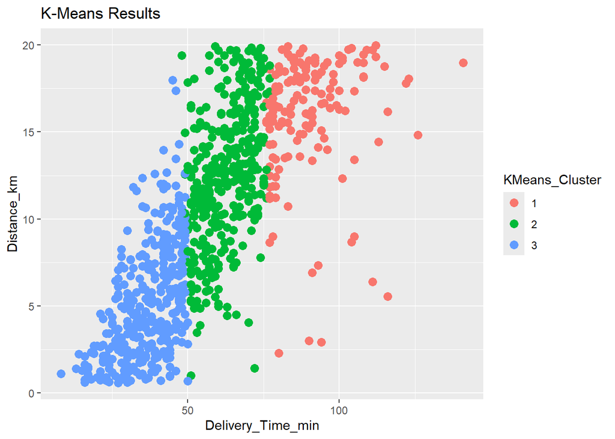

   ```r
   library(ggplot2)

   cluster_centers <- as.data.frame(kmeans$centers)
   cluster_centers$Cluster <- factor(1:3)

   ggplot(data4, aes(x = Delivery_Time_min, y = Distance_km, color = KMeans_Cluster)) +
     geom_point(size=3) +
     labs(title = "K-Means Results", x = "Delivery_Time_min", y = "Distance_km")
   ```

   If the top of the blue cluster was green and the top of the green cluster was red, a more successful clustering would have been achieved.
3. Make your final comments clearly.

   The K-Means results look good in general. However, as the Delivery_Time_min values increase, there are clustering failures. If the top of the blue cluster was included in the green cluster and the top of the green cluster was included in the red cluster, we could have seen a better result.

#### AGGLOMERATIVE CLUSTERING

1. Use appropriate functions and arguments.

   ```r
   set.seed(11)
   distance_matrix <- dist(data4[, c("Distance_km", "Delivery_Time_min")], method = "euclidean")
   agglo_hclust <- hclust(distance_matrix, method = "average")
   k_clusters <- cutree(agglo_hclust, k = 3)

   data4$Agglo_Cluster <- as.factor(k_clusters)
   ```

2. Use visualization techniques. Describe the result!

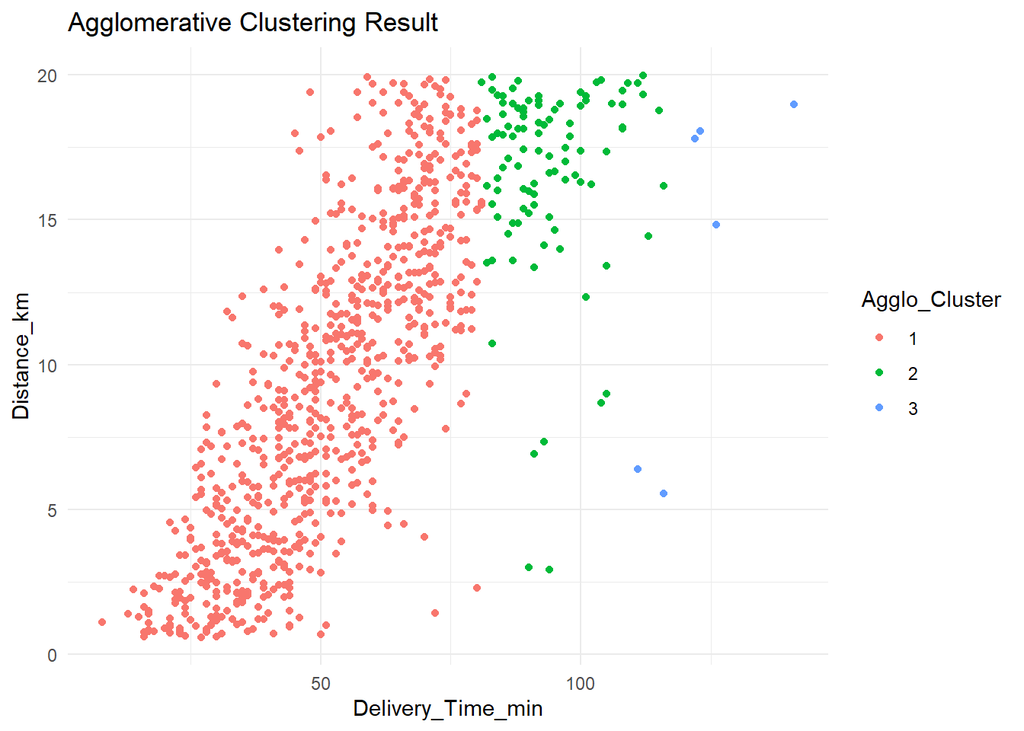

   ```r
   ggplot(data4, aes(x = Delivery_Time_min, y = Distance_km, color = Agglo_Cluster)) +
     geom_point() +
     labs(title = "Agglomerative Clustering Result", x = "Delivery_Time_min", y = "Distance_km") +
     theme_minimal()
   ```

   This is bad at the higher Distance_km values.
3. Make your final comments clearly.

   The model clustered well for low Distance_km values, but as the Distance_km value increases, I see that the clustering becomes worse. Since I know that the time increases as the distance increases, I expected the clustering to be like 3 bubbles going diagonally up and to the right.

b. Compare the results you have found.

I would choose the K-Means algorithm for this dataset. Because it seems more suitable for the cluster I expected and it separated the clusters more accurately. Both algorithms were confused for high values, but I can say that K-Means gave more accurate results.

### 8. Apply one more 2 Classification Technique other than logreg.

a. Describe the reasons you choose those 2 techniques.

I chose Decision Tree for its simplicity and interpretability, making it easy to understand and visualize decision-making. Random Forest was selected for its ability to improve accuracy by combining multiple trees, reducing overfitting, and providing insights into feature importance.

#### DECISION TREE

1. Use appropriate functions and arguments.

   ```r
   library(rpart)

   data5 <- data
   data5 <- data5[, !names(data5) %in% "Cluster"]

   data5$Weather <- as.factor(data5$Weather)
   data5$Traffic_Level <- as.factor(data5$Traffic_Level)
   data5$Time_of_Day <- as.factor(data5$Time_of_Day)
   data5$Vehicle_Type <- as.factor(data5$Vehicle_Type)

   data5$Weather <- as.numeric(data5$Weather)
   data5$Traffic_Level <- as.numeric(data5$Traffic_Level)
   data5$Time_of_Day <- as.numeric(data5$Time_of_Day)
   data5$Vehicle_Type <- as.numeric(data5$Vehicle_Type)

   tree_model <- rpart(data5$Delivery_Time_min ~ ., data = data5[, -c(1, 9)], method = "anova")
   ```

2. Use visualization techniques. Describe the result!

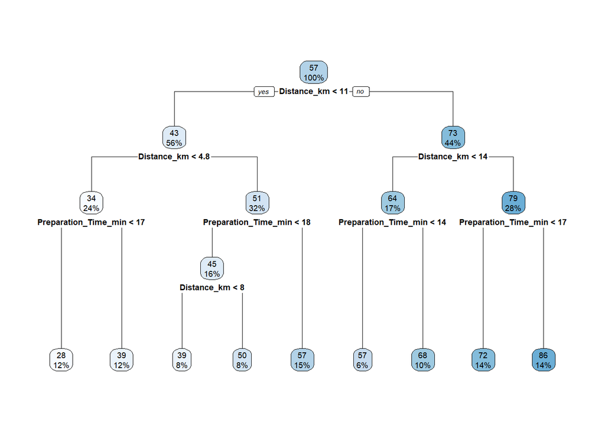

   ```r
   library(rpart.plot)
   rpart.plot(tree_model)
   ```

   ```r
   predictions <- predict(tree_model, newdata = data5[, -c(1, 9)])
   actual_values <- data5$Delivery_Time_min

   MAE <- mean(abs(predictions - actual_values))
   MSE <- mean((predictions - actual_values)^2)
   RMSE <- sqrt(MSE)
   SSE <- sum((predictions - actual_values)^2)
   SST <- sum((actual_values - mean(actual_values))^2)
   R2 <- 1 - (SSE / SST)

   cat("MAE:", MAE, "\n")
   ```

   ```
   ## MAE: 8.899539
   ```

   ```r
   cat("MSE:", MSE, "\n")
   ```

   ```
   ## MSE: 158.5326
   ```

   ```r
   cat("RMSE:", RMSE, "\n")
   ```

   ```
   ## RMSE: 12.59097
   ```

   ```r
   cat("R-squared:", R2, "\n")
   ```

   ```
   ## R-squared: 0.6742291
   ```

   MAE : This indicates that, on average the models predictions are off by about 8.90 mins.

   MSE : This suggest that the average squered error between predicted and actual values is 158.5.

   RMSE : RMSE is 12.5 meaning the typical prediction error is around 12.5 mins.

   R-squared : This means that %67.42 of the variation in Delivery_Time_min is explained by the features.

1. Use appropriate functions and arguments.

   ```r
   library(randomForest)
   data5_clean <- na.omit(data5)
   rf_model <- randomForest(Delivery_Time_min ~ ., data = data5_clean, ntree = 100)
   ```

2. Use visualization techniques. Describe the result!

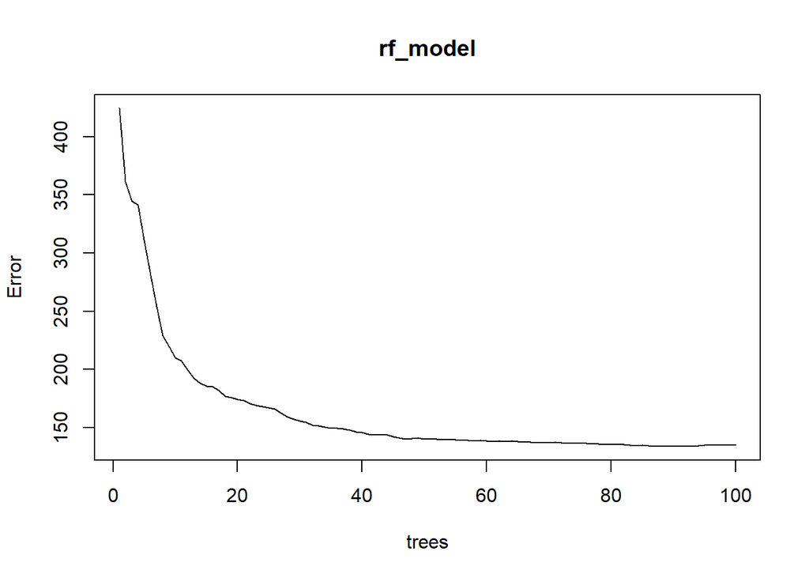

   ```r
   plot(rf_model)
   ```

   The more trees, the less error occur.
3. Calculate the performance scores. Make your final comments clearly.

   ```r
   predictions <- predict(rf_model, data5_clean)

   MAE <- mean(abs(predictions - data5_clean$Delivery_Time_min))
   MSE <- mean((predictions - data5_clean$Delivery_Time_min)^2)
   RMSE <- sqrt(MSE)

   SS_total <- sum((data5_clean$Delivery_Time_min - mean(data5_clean$Delivery_Time_min))^2)
   SS_residual <- sum((data5_clean$Delivery_Time_min - predictions)^2)
   R_squared <- 1 - (SS_residual / SS_total)

   # Print the results
   cat("MAE:", MAE, "\n")
   ```

   ```
   ## MAE: 4.084162
   ```

   ```r
   cat("MSE:", MSE, "\n")
   ```

   ```
   ## MSE: 35.68069
   ```

   ```r
   cat("RMSE:", RMSE, "\n")
   ```

   ```
   ## RMSE: 5.973332
   ```

   ```r
   cat("R-squared:", R_squared, "\n")
   ```

   ```
   ## R-squared: 0.9232133
   ```

### X. Use the PCA results you have found in step 5; and re-implement just one of the classification technique you used. Compare : “results with original data” and “results with components”, make your comments.

For this chapter, I will use Random Forest Classifier from 8.2.

At first , we need to convert pca_data to a data frame.

```r
numerical_cols_clean <- data5_clean[, c("Distance_km", "Preparation_Time_min", "Courier_Experience_yrs", "Delivery_Time_min")]

num_data_scaled_clean <- scale(numerical_cols_clean)

pca_clean <- prcomp(num_data_scaled_clean, center = TRUE, scale. = TRUE)

pca_data <- as.data.frame(pca_clean$x)

pca_data$Delivery_Time_min <- data5_clean$Delivery_Time_min

print(head(pca_data))
```

```
##          PC1        PC2        PC3          PC4 Delivery_Time_min
## 1 -0.7547875  0.3350664  1.3669302  0.074638108                43
## 2  1.8116272  0.4588219  0.6162894 -0.008887796                84
## 3  0.4739725  1.8763116  0.1256833  0.317866549                59
## 4 -1.2356175 -0.3511662  1.9137479 -0.040641510                37
## 5  1.3795005 -0.7047489  0.1845088  0.616626255                68
## 6  0.6965113 -2.3412895 -0.2692271  0.657046194                57
```

Now, I can reimplement Random Forest using PCA data.

```r
library(randomForest)
rf_model_pca <- randomForest(Delivery_Time_min ~ ., data = pca_data, ntree = 100)

predictions_pca <- predict(rf_model_pca, newdata = pca_data)
mae_pca <- mean(abs(predictions_pca - pca_data$Delivery_Time_min))
mse_pca <- mean((predictions_pca - pca_data$Delivery_Time_min)^2)
rmse_pca <- sqrt(mse_pca)
r_squared_pca <- 1 - (sum((predictions_pca - pca_data$Delivery_Time_min)^2) /
                      sum((pca_data$Delivery_Time_min - mean(pca_data$Delivery_Time_min))^2))
```

Let’s check the results.

```r
cat("MAE:", mae_pca, "\n")
```

```
## MAE: 1.464667
```

```r
cat("MSE:", mse_pca, "\n")
```

```
## MSE: 4.502278
```

```r
cat("RMSE:", rmse_pca, "\n")
```

```
## RMSE: 2.121857
```

```r
cat("R-squared:", r_squared_pca, "\n")
```

```
## R-squared: 0.9903109
```

### Y. Missing Data Imputation.

1. Use an imputation method to impute those NA value. Continue with complete data for the following steps.

   ```r
   library(mice)
   data$Weather <- as.factor(data$Weather)
   data$Traffic_Level <- as.factor(data$Traffic_Level)
   data$Time_of_Day <- as.factor(data$Time_of_Day)
   data$Vehicle_Type <- as.factor(data$Vehicle_Type)

   methods <- make.method(data)

   methods[["Courier_Experience_yrs"]] <- "norm.predict"
   methods[["Preparation_Time_min"]] <- "norm.predict"
   methods[["Distance_km"]] <- "norm.predict"

   methods[["Weather"]] <- "polyreg"
   methods[["Traffic_Level"]] <- "polyreg"
   methods[["Time_of_Day"]] <- "polyreg"
   methods[["Vehicle_Type"]] <- "polyreg"

   data_imputed <- mice(data, m = 1, method = methods, seed = 123)
   data_imputed <- complete(data_imputed)
   ```

   To see is there any missing value :

   ```r
   anyNA(data_imputed)
   ```

   ```
   ## [1] FALSE
   ```

   There is no missing data.
2. Apply the classification applications (6 or 8.1 or 8.2). Apply the classification “data with missing values” and “data with imputed values.” Compare the “results with missing values” and “result with imputed values”. Which performance score you choose? What is your final decision?

   I will use Random Forest again.

   ```r
   library(randomForest)
   rf_imputed <- randomForest(Delivery_Time_min ~ ., data = data_imputed, ntree = 100)
   pred_imputed <- predict(rf_imputed, data_imputed)
   mae_imputed <- mean(abs(pred_imputed - data_imputed$Delivery_Time_min))
   mse_imputed <- mean((pred_imputed - data_imputed$Delivery_Time_min)^2)
   rmse_imputed <- sqrt(mse_imputed)
   r_squared_imputed <- 1 - sum((pred_imputed - data_imputed$Delivery_Time_min)^2) /
                           sum((mean(data_imputed$Delivery_Time_min) - data_imputed$Delivery_Time_min)^2)
   ```

   Now, see the results for imputed values.

   ```r
   cat("MAE:", mae_imputed, "\n")
   ```

   ```
   ## MAE: 4.019642
   ```

   ```r
   cat("MSE:", mse_imputed, "\n")
   ```

   ```
   ## MSE: 34.49531
   ```

   ```r
   cat("RMSE:", rmse_imputed, "\n")
   ```

   ```
   ## RMSE: 5.873271
   ```

   ```r
   cat("R-squared:", r_squared_imputed, "\n")
   ```

   ```
   ## R-squared: 0.9291151
   ```

   As we can see here, our values have improved very, very slightly. The reason for this improvement may be that the missing values are less than the number of total rows. At this point, even if there is not much change between them, I choose the data that has no missing values and train my model.

### Z. Imbalanced dataset.

1. Use oversampling, undersampling or both, to balance your data. Continue with the balanced data for the following steps.

   I will use both on Logistic Regression that I have implement at 6.

   ```r
   library(nnet)

   data2 <- data[complete.cases(data), ]

   car_samples <- data2[data2$Vehicle_Type == "Car", ]
   scooter_samples <- data2[data2$Vehicle_Type == "Scooter", ]
   bike_samples <- data2[data2$Vehicle_Type == "Bike", ]

   set.seed(10)

   car_samples <- car_samples[sample(nrow(car_samples), 150), ]
   scooter_samples <- scooter_samples[sample(nrow(scooter_samples), 150), ]
   bike_samples <- bike_samples[sample(nrow(bike_samples), 150), ]

   data2 <- rbind(car_samples, scooter_samples, bike_samples)
   data2 <- data2[sample(nrow(data2)), ]

   multinom_model <- multinom(Vehicle_Type ~ Distance_km + Weather + Traffic_Level + Time_of_Day + Preparation_Time_min + Courier_Experience_yrs + Delivery_Time_min, data = data2)
   summary(multinom_model)
   ```

   ```
   ## Call:
   ## multinom(formula = Vehicle_Type ~ Distance_km + Weather + Traffic_Level +
   ##     Time_of_Day + Preparation_Time_min + Courier_Experience_yrs +
   ##     Delivery_Time_min, data = data2)
   ##
   ## Coefficients:
   ##         (Intercept) Distance_km WeatherFoggy WeatherRainy WeatherSnowy
   ## Car      -0.4214232  0.01388647   -0.0751981    0.3679251    0.2728886
   ## Scooter   0.2208724  0.06260696   -0.1994207    0.2855452   -0.7471138
   ##         WeatherWindy Traffic_LevelLow Traffic_LevelMedium Time_of_DayEvening
   ## Car        0.2338153       0.39482650         -0.03828682         -0.1238880
   ## Scooter   -0.2766037       0.01109625          0.09619231         -0.4007215
   ##         Time_of_DayMorning Time_of_DayNight Preparation_Time_min
   ## Car              0.2713060       -0.6402158           0.01270579
   ## Scooter         -0.3616704       -1.1558141           0.03155142
   ##         Courier_Experience_yrs Delivery_Time_min
   ## Car                -0.06122366       0.001938212
   ## Scooter            -0.04678761      -0.014343683
   ##
   ## Std. Errors:
   ##         (Intercept) Distance_km WeatherFoggy WeatherRainy WeatherSnowy
   ## Car       0.5919499  0.03967188    0.4099992    0.3318332    0.3942288
   ## Scooter   0.5901025  0.04269294    0.4129152    0.3243592    0.4829313
   ##         WeatherWindy Traffic_LevelLow Traffic_LevelMedium Time_of_DayEvening
   ## Car        0.3997287        0.3568142           0.3342065          0.3145341
   ## Scooter    0.4163832        0.3748588           0.3343077          0.3025153
   ##         Time_of_DayMorning Time_of_DayNight Preparation_Time_min
   ## Car              0.3042923        0.4568386           0.01886546
   ## Scooter          0.3037230        0.4613607           0.01972727
   ##         Courier_Experience_yrs Delivery_Time_min
   ## Car                 0.04243923        0.01093134
   ## Scooter             0.04253679        0.01224431
   ##
   ## Residual Deviance: 953.8947
   ## AIC: 1009.895
   ```

2. In just one of your applications(6 or 8.1 or 8.2), apply the classification algorithm to “imbalanced data” and “balanced data”. Compare the “results with imbalanced data” and “results with non-balanced data”. Which performance score you choose? What is your final decision.

[figure not shown]

   ```r
   library(caret)
   library(ggplot2)

   predictions <- predict(multinom_model, newdata = data2, type = "class")
   conf_matrix <- confusionMatrix(factor(predictions), factor(data2$Vehicle_Type))
   conf_matrix_df <- as.data.frame(as.table(conf_matrix$table))

   colnames(conf_matrix_df) <- c("Actual", "Predicted", "Freq")

   ggplot(conf_matrix_df, aes(x = Actual, y = Predicted, fill = Freq)) +
     geom_tile() +
     geom_text(aes(label = Freq), color = "white", size = 4) +
     scale_fill_gradient(low = "white", high = "black") +
     labs(title = "Confusion Matrix", x = "Actual", y = "Predicted") +
     theme_minimal()
   ```

   ```r
   print(conf_matrix)
   ```

   ```
   ## Confusion Matrix and Statistics
   ##
   ##           Reference
   ## Prediction Bike Car Scooter
   ##    Bike      54  41      38
   ##    Car       40  64      29
   ##    Scooter   56  45      83
   ##
   ## Overall Statistics
   ##
   ##                Accuracy : 0.4467
   ##                  95% CI : (0.4001, 0.4939)
   ##     No Information Rate : 0.3333
   ##     P-Value [Acc > NIR] : 3.855e-07
   ##
   ##                   Kappa : 0.17
   ##
   ##  Mcnemar's Test P-Value : 0.07454
   ##
   ## Statistics by Class:
   ##
   ##                      Class: Bike Class: Car Class: Scooter
   ## Sensitivity               0.3600     0.4267         0.5533
   ## Specificity               0.7367     0.7700         0.6633
   ## Pos Pred Value            0.4060     0.4812         0.4511
   ## Neg Pred Value            0.6972     0.7287         0.7481
   ## Prevalence                0.3333     0.3333         0.3333
   ## Detection Rate            0.1200     0.1422         0.1844
   ## Detection Prevalence      0.2956     0.2956         0.4089
   ## Balanced Accuracy         0.5483     0.5983         0.6083
   ```

   My preference would be to use non-balanced data because the model has a higher ability to correctly predict the Bike class and generally this type of model can focus more on correctly classifying important classes.